# Simulations

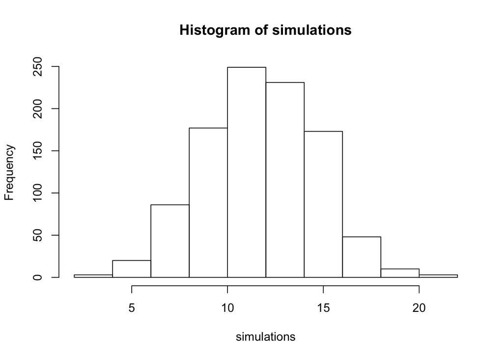

```r
simulations <- rbinom(n = 1000, size = 39, prob = .309)

hist(simulations)
```

```r
table(simulations)
```

```
## simulations
##   2   4   5   6   7   8   9  10  11  12  13  14  15  16  17  18  19  20
##   1   2   6  14  31  55  68 109 116 133 141  90  96  77  34  14   7   3
##  21  22
##   1   2
```

So what we see is given his season long shooting percentage, it’s not out of the realm of randomness that with just 39 attempts for Palmer, he’s only hit only 7. Is he below where he should be? Yes. Will he likely improve and soon? Yes.

### Cold streaks

During the Western Illinois game, the team, shooting .329 on the season from behind the arc, went 0-15 in the second half. How strange is that?

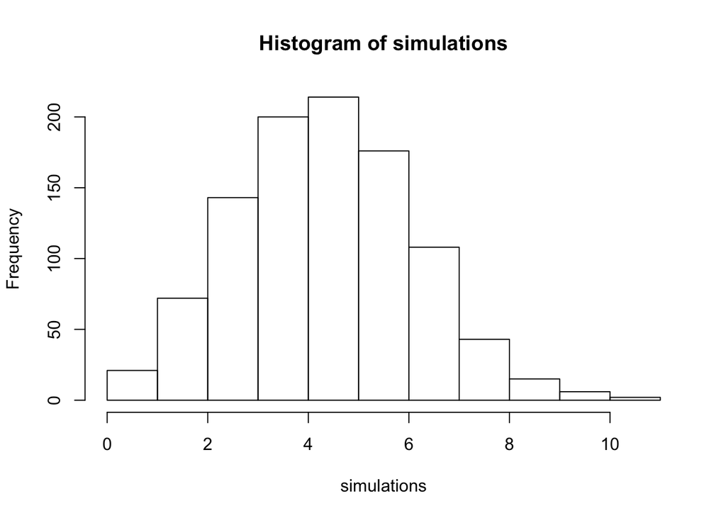

```r
simulations <- rbinom(n = 1000, size = 15, prob = .329)

hist(simulations)
```

```r
table(simulations)
```

```
## simulations
##   0   1   2   3   4   5   6   7   8   9  10  11
##   4  17  72 143 200 214 176 108  43  15   6   2
```

Short answer: Really weird. If you simulate 15 threes 1000 times, sometimes you’ll see them miss all of them, but only a few times. Sometimes, they don’t go 0-15 even once. So going ice cold is not totally out of the realm of random chance, but it’s highly unlikely. That’s trouble going into a game with a good team like Clemson.